# Day 6 Notebook

```r
### Read in time and distances
mytimes <- read_lines("Day6Sample.txt",n_max=1)
mydistances <- read_lines("Day6Sample.txt",n_max=1,skip=1)
```

## Part 1

The goal is to make sure that the boat goes longer than the record

how far is it going to go? The basic formula is distance(d) = rate(r) x time(t).

$$d=r*t$$

the rate will be equal to the number of seconds that the button was pressed. And the time will be equal to the race time-button press time:

$$d=b*(T-b)$$

So for the first of the examples (a seven second race - T=7; record of 9 (d=9)), the plot of the distance looks like this:

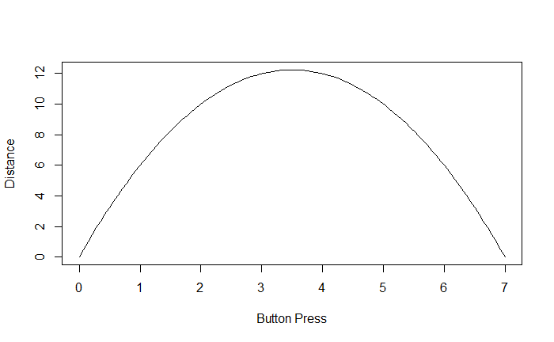

But no one cares about the whole thing - all that matters is the part where the distance is more than 9. So this is the curve that really matters:

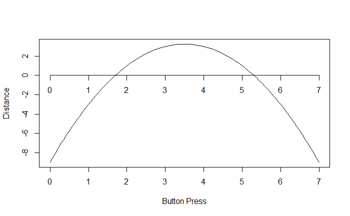

And the integers between the 0s (where the curve crosses the axis) are the ones that count - for this one, 2, 3, 4, and 5 - are all valid button press times. So the answer would be 4.

To find where the curve crosses the line, subtract the distance and solve for b using the quadratic equation

$$-b^2+Tb-d=0$$

$$b=\frac{-T\pm\sqrt(T^2-4d)}{-2}$$

So starting with taking in the times and distances and putting them nicely into a data frame

```r
mytimes <- as.numeric(unlist(str_split(str_squish(str_trim(str_split_i(mytimes,":",2)))," ")))
mydistances <- as.numeric(unlist(str_split(str_squish(str_trim(str_split_i(mydistances,":",2)))," ")))

findoptions <-data.frame(mytimes,mydistances)
colnames(findoptions)<-c("times", "distances")
findoptions
```

| times | distances |
| --- | --- |
| 7 | 9 |
| 15 | 40 |
| 30 | 200 |

From there, use the earlier former to find the upper and lower 0

```r
findoptions <- findoptions %>% mutate(lowzero=.5*(times-sqrt(times^2-(4*distances))),
                                      upzero=.5*(times+sqrt(times^2-(4*distances))))
findoptions
```

| times | distances | lowzero | upzero |
| --- | --- | --- | --- |
| 7 | 9 | 1.697224 | 5.302776 |
| 15 | 40 | 3.468871 | 11.531129 |
| 30 | 200 | 10.000000 | 20.000000 |

And now, find the next the integer below the upzero and the integer above the lowzero (warning, take note if the zero is itself an integer! It doesn’t count, that’s where the boat is just as fast as record, not faster)

```r
findoptions <- findoptions %>% mutate(lowint=ifelse(is_wholenumber(lowzero),lowzero+1,ceiling(lowzero)),
                                      upint=ifelse(is_wholenumber(upzero),upzero-1,floor(upzero)))
findoptions
```

| times | distances | lowzero | upzero | lowint | upint |
| --- | --- | --- | --- | --- | --- |
| 7 | 9 | 1.697224 | 5.302776 | 2 | 5 |
| 15 | 40 | 3.468871 | 11.531129 | 4 | 11 |
| 30 | 200 | 10.000000 | 20.000000 | 11 | 19 |

finally, find the number of integers between the upper and lower integers (inclusive):

```r
findoptions <- findoptions %>% mutate(recordbeating=upint-lowint+1)
findoptions
```

| times | distances | lowzero | upzero | lowint | upint | recordbeating |
| --- | --- | --- | --- | --- | --- | --- |
| 7 | 9 | 1.697224 | 5.302776 | 2 | 5 | 4 |
| 15 | 40 | 3.468871 | 11.531129 | 4 | 11 | 8 |
| 30 | 200 | 10.000000 | 20.000000 | 11 | 19 | 9 |

```r
part1<-prod(findoptions$recordbeating)
part1
```

```
[1] 288
```

## Part 2

then do the same thing

```r
findoptions <-data.frame(mytimes,mydistances)
colnames(findoptions)<-c("times", "distances")
findoptions <- findoptions %>% mutate(lowzero=.5*(times-sqrt(times^2-(4*distances))),
                                      upzero=.5*(times+sqrt(times^2-(4*distances))))
findoptions <- findoptions %>% mutate(lowint=ifelse(is_wholenumber(lowzero),lowzero+1,ceiling(lowzero)),
                                      upint=ifelse(is_wholenumber(upzero),upzero-1,floor(upzero)))
findoptions <- findoptions %>% mutate(recordbeating=upint-lowint+1)
```

```r
part2 <- findoptions$recordbeating
part2
```

[output not shown]

Finally - single function (from the file)

```r
day6answers<-function(infile){
  mytimes <- read_lines(infile,n_max=1)
  mydistances <- read_lines(infile,n_max=1,skip=1)
  ##transform
  mytimes <- as.numeric(unlist(str_split(str_squish(str_trim(str_split_i(mytimes,":",2)))," ")))
  mydistances <- as.numeric(unlist(str_split(str_squish(str_trim(str_split_i(mydistances,":",2)))," ")))

  ##create dataframe
  findoptions <-data.frame(mytimes,mydistances)
  colnames(findoptions)<-c("times", "distances")
  findoptions <- findoptions %>%
    ## do the math
    mutate(lowzero=.5*(times-sqrt(times^2-(4*distances))),
           upzero=.5*(times+sqrt(times^2-(4*distances)))) %>%
    mutate(lowint=ifelse(is_wholenumber(lowzero),lowzero+1,ceiling(lowzero)),
           upint=ifelse(is_wholenumber(upzero),upzero-1,floor(upzero))) %>%
    mutate(recordbeating=upint-lowint+1)
  part1<-prod(findoptions$recordbeating)

  ## transform again
  mytimes<-as.numeric(str_flatten(as.character(mytimes),collapse=""))
  mydistances <-as.numeric(str_flatten(as.character(mydistances),collapse=""))
  findoptions <-data.frame(mytimes,mydistances)
  colnames(findoptions)<-c("times", "distances")
  findoptions <- findoptions %>%
    mutate(lowzero=.5*(times-sqrt(times^2-(4*distances))),
           upzero=.5*(times+sqrt(times^2-(4*distances)))) %>%
    mutate(lowint=ifelse(is_wholenumber(lowzero),lowzero+1,ceiling(lowzero)),
           upint=ifelse(is_wholenumber(upzero),upzero-1,floor(upzero))) %>%
    mutate(recordbeating=upint-lowint+1)
  part2 <- findoptions$recordbeating

  c(part1,part2)
}
```

```r
day6<-day6answers("Day6Sample.txt")
day6
```

```
[1]   288 71503
```